# 01.04.01.00.RelatividadEspecial.CinematicaRelativista.Definiciones

Indice | Previo: RelatividadEspecial.Minkowski | Siguiente: RelatividadEspecial.CinematicaRelativista.AceleracionPropiaConstante

## 1.11. Cinemática relativistica

### 1.11.1. Motivación

En las secciones precedentes construímos las bases teóricas de una relatividad que es consistente con la covarianza de las ecuaciones de Maxwell. Al hacerlo descubrimos propiedades completamente nuevas del espacio y el tiempo de las que no fuimos conscientes antes del advenimiento de las ideas de Albert Einstein y Mileva Maric.

Entre los resultados más sorprendentes que obtuvimos está aquel de que la velocidad de la luz es una velocidad máxima entre los observadores inerciales y por extensión entre cualquier partícula o sistema que se mueva siguiendo una línea de universo temporaloide (que satisface relaciones de causalidad).

Este resultado esta sin embargo en abierta contradicción con la cinemática que permite, dada una aceleración arbitraria conseguir una velocidad arbitraria también. Así por ejemplo, si la aceleración de una partícula es constante $\vec a_0$ tal y como es medida en el laboratorio, de acuerdo a un resultado elemental de la cinemática su velocidad será:

$$ \vec v = \vec a_0 t $$

Transcurrido el tiempo suficiente (exactamente $t=c/a_0$) un cuerpo animado con cualquier aceleración conseguirá alcanzar la velocidad de la luz, e incluso superar la barrera. ¿Qué puede estar mal en la cinemática? ¿no es la cinemática nada más que una descripción (sin compromiso con una teoría física específica) del movimiento?

En las siguientes secciones construiremos una nueva cinemática sobre la base de los postulados físicos y matemáticos definidos en las secciones precedentes. El objetivo primario de este esfuerzo será el de deducir una descripción nueva del movimiento en la que, por un lado, no se produzcan situaciones paradójicas como las mencionadas antes y por el otro, la descripción sea rigurosa en el espacio-tiempo.

### 1.11.2. Descripción de una línea de universo

El movimiento de los cuerpos se realiza en el continuo cuadridimensional del espacio-tiempo. Cualquier descripción del movimiento debe ser una descripción de su trayectoria en cuatro dimensiones, su línea de universo como definimos previamente.

En el espacio de Minkowski (en el que se puede definir un sistema de referencia-espacio temporal global) cada punto sobre una línea de universo esta descrito por el cuadrivector posición:

$$ \tilde x :(t,\vec r_L) $$

donde en lo sucesivo usaremos los ":" para indicar que una cosa es el cuadrivector abstracto $\tilde x$ y su representación como una tupla de componentes espacio temporales, que en coordenadas cartesianas serán:

$$ x^0 = t, x^1 = x, x^2 = y, x^3 = z $$

Cada punto en una línea de universo se distingue del otro por un parámetro abritrario $\lambda$. Como se acostumbra en el cálculo diferencial y en la cinemática clásica este parámetro puede escogerse de muchas maneras. Es corrinete usar la longitud de arco $\ell$ en cálculo o el tiempo $t$ en cinemática.

En el contexto de la relatividad, sin embargo, es conveniente escoger un parámetro que no cambie al cambiar de sistema de referencia inercial. Esto es, la idea es que el número que usemos para identificar cada punto de la línea de universo sea el mismo independientemente del sistema de referencia que usemos.

En la sección anterior vimos que el *intervalo* $s$, medido como la longitude de la línea de uinverso respecto a un punto de referencia, es el candidato perfecto. Por definición es una cantidad invariante. Pero vimos también que en virtud del postulado de los relojes, $s$ es equivalente al tiempo propio $\tau$ medido sobre la línea de universo respecto al mismo punto de referencia.

[figure not shown]

**Figura 1.11**. Trayectoria en el espacio-tiempo

Esa es la distinción fundamental entre la cinemática clásica en el espacio y la cinemática en cuatro dimensiones.

### 1.11.3. Cuadrivelocidad

En secciones precedentes habíamos definito ya las dos cantidades cinemáticas básicas en el espacio-tiempo.

Definimos la cuadrivelocidad media de una partícula que se mueve entre dos eventos separados por un intervalo temporaloide como:

$$ \langle \tilde U\rangle=\frac{\Delta \tilde{x}}{\Delta \tau} $$

donde $\Delta\tau$ es el tiempo propio entre los eventos.

Usando el mismo método de la mecánica convencional podemos extender este concepto al de cuadrivelocidad instantánea:

$$ \tilde U=\lim_{\Delta \tau\rightarrow 0}\frac{\Delta \tilde x^\mu}{\Delta \tau}=\frac{\mathrm{d}\tilde{x}}{\mathrm{d}\tau} $$

En términos de componentes explícitas:

$$ \tilde U:\left(\frac{\mathrm{d}t}{\mathrm{d}\tau},\frac{\mathrm{d}\vec{r}_L}{\mathrm{d}\tau}\right) $$

Usando el hecho que $\mathrm{d}\tau=\mathrm{d}t/\gamma$, la derivada respecto a $\tau$ en lo sucesivo será:

$$ \frac{\mathrm{d}}{\mathrm{d\tau}}=\gamma\frac{\mathrm{d}}{\mathrm{dt}} $$

$$ \tilde U:\gamma\left(1,\vec{v}_L\right) $$

donde hemos definido

$$ \vec{v}_L\equiv\frac{\mathrm{d}x_L^\mu}{\mathrm{d}t} $$

**Proposición: Cuadrirapidez constante.** Todas las partículas del universo ($v_L<1$) tienen la misma cuadrirapidez:

> $$ |\tilde U|_L=1 $$

> o en unidades convencionales: $$ |\tilde U|=c $$

> Un resultado que podríamos también formular diciendo que en el espacio-tiempo de Minkowski todas las partículas se mueven con la rapidez de la luz.

Un gráfico de todas las cuadrivelocidades de todas las partículas en el universo son:

```python
%matplotlib inline
```

[output not shown]

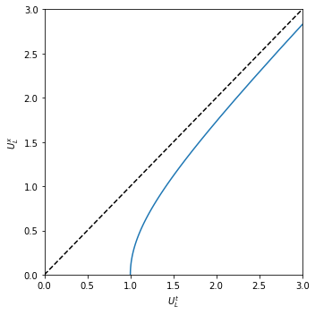

```python
from numpy import linspace
vl=linspace(0,0.95)
gamma=1/(1-vl**2)**0.5
U0=gamma
Ux=gamma*vl

import matplotlib.pyplot as plt
fig=plt.figure(figsize=(5,5))
ax=fig.gca()

ax.plot(U0,Ux)
ax.set_xlim((0,3))
ax.set_ylim((0,3))
ax.plot([0,3],[0,3],'k--')
ax.set_xlabel("$U_L^t$")
ax.set_ylabel("$U_{L}^{x}$")
fig.tight_layout()
```

**Figura 1.12.**

Si incluímos las 3 dimensiones espaciales, todas las cuadrivelocidades del universo están sobre un hiper-hiperboloide de revolución (alrededor del eje $t$):

$$ 1 = (U_L^0)^2 - (U_L^1)^2-(U_L^2)^2-(U_L^3)^2 $$

### 1.11.4. Cuadriaceleración

De la misma manera que definimos la cuadrivelocidad promedio, podemos definir la cuadriaceleración promedio:

$$ \langle\tilde A\rangle=\frac{\Delta \tilde U}{\Delta \tau} $$

La aceleración instantánea sería:

$$ \tilde A=\lim_{\Delta \tau\rightarrow 0}\frac{\Delta \tilde U}{\Delta \tau}=\frac{\mathrm{d}\tilde U}{\mathrm{d}\tau}=\frac{\mathrm{d}^2\tilde x}{\mathrm{d}\tau^2} $$

Usando el hecho que $\tilde U:(\gamma,\gamma \vec v_L)$, podemos obtener la aceleración con el siguiente procedimiento de `SymPy`. Primero definimos las variables y funciones básicas:

```python
import sympy as sp

#Definimos las variables
t=sp.symbols("t")

#Definimos las funciones básicas
v=sp.Function("v")

#Cantidades derivadas
g=1/sp.sqrt(1-v(t)**2)
```

Después de las definiciones podemos proceder:

```python
#Definición de la cuadrivelocidad
U=sp.Array([g,v(t)*g])

#Cálculamos la cuadriaceleración
A=g*sp.simplify(sp.diff(U,t))
A
```

$\displaystyle \left[\begin{matrix}\frac{v{\left(t \right)} \frac{d}{d t} v{\left(t \right)}}{\left(1 - v^{2}{\left(t \right)}\right)^{2}} & \frac{\frac{d}{d t} v{\left(t \right)}}{\left(1 - v^{2}{\left(t \right)}\right)^{2}}\end{matrix}\right]$

De donde obtenemos finalmente que en la configuración estándar:

$$ A^\mu_L : \gamma^4 (a_{xL}v_{xL},a_{xL}) $$

donde $a=\mathrm{d}v_{xL}/\mathrm{d}t$ es la aceleración espacial.

En la configuración general:

$$ A^\mu_L : \gamma^4 (\vec{a}_L\cdot \vec{v}_L,\vec{a}_L) $$

Naturalmente aquí $\vec{a}_L\cdot \vec{v}_L$ es el producto punto euclidiano.

**Nota: De unidades luz a unidades convencionales.** Si en un problema dado obtenemos el desplazamiento, la velocidad (cuadrivelocidad) o la acelaración (cuadriaceleración) en unidades luz, podemos volver a obtener las unidades originales como:

> $$ \begin{array}{rcl} \Delta \vec{r} & = & c \Delta \vec{r}_L\\ \vec{v} & = & c \vec{v}_L\\ \vec{a} & = & c \vec{a}_L\\ \end{array} $$

> Con estas transformaciones, la cuadriaceleración se puede escribir como:

> $$A^\mu : c\gamma^4\left(\frac{\vec{a}\cdot\vec{v}}{c^2},\frac{\vec{a}}{c}\right)$$

Nótese que si $\vec{v}_L=\vec{o}$ entonces:

$$ A_L^\mu:(0,\vec \alpha_L) $$

de donde vemos que el módulo cuadrado de la cuadriaceleración es espacialoide:

$$ |A_L^\mu|^2 = -\alpha_L^2 $$

Dado que esta cantidad es invariante (la misma para el Observador y el viajero) llamamos a $\alpha_L$ la aceleración propia de la partícula.

**Proposición: La relación entre la cuadriaceleración y la cuadrivelocidad.** La cuadrivelocidad y la cuadriaceleración son perpendiculares:

> $$A^\mu\cdot U^\nu = 0$$

Indice | Previo: RelatividadEspecial.Minkowski | Siguiente: RelatividadEspecial.CinematicaRelativista.AceleracionPropiaConstante